# Soil water potential pre-analysis

Anne Baranger

24/02/2022

# Introduction

To assess the hydraulic stress experienced by species in different climatic context we compute the distance between hydraulic resistance and hydric constraints of the environment. Hydraulic resistance is measured by the hydraulic potential at which 50% of the vessels of a species are embolized. Hydric constraints is assessed by the minimum soil hydraulic potential. Indeed, hydraulic potential is supposed to range between that of the soil and of the air. However, plant potential is regulated by stomatal closure that enables potential not to drop beneath critical values. Therefore it is assumed that soil potential sets the upper limit of plant potential.

## Minimum soil potential theoritical computation

Minimum soil potential $\Psi_{min}$ is not a largescale measured parameter, it needs to be computed according physical assumptions. It requires soil water content (SWC) and parameter associated to soil texture. Different methods have been proposed to this end:

- Campbell equation $\Psi_{min} = \Psi_{e} \cdot (SWC_{max}/SWC_{min})^b$ with SWC being soil water content, $\Psi_{e}$ and $b$ paramaters that depend on local soil texture
- van Genuchten equation $\Psi_{min}= [ (\frac{\theta_s - \theta_r}{SWC_{min}-\theta_r})^{1/m}-1]^{1/n} \cdot \frac{1}{\alpha}$

$\Psi_e$, $b$, $\theta_s$, $\theta_r$, $n$, $m$, $\alpha$ are parameters computed based on soil texture or fitted over empirical data.

For Campbell equation, we computed parameters according to the formula given in the related book (Campbell 1985). For Van Genuchten, we proceed a litterature review to extract parameters fitted over datasets that corresponds to the range of our study, ie Europe (Wösten et al. 1999).

Soil water content can be computed from direct climatic database or from water balance based on simple bucket model.

## Available dataset

The analysis is conducted over geographical Europe, excluding Russia. We choose to compute soil potential from two available datasets:

- Era5-land that provides monthly measures of soil water content at 9x9km resolution for 4 soil layers, over the 1950-2021 period ;
- ESDAC that provides soil texture at 1x1km resolution.

Temporal series of SWC enabled to compute minimum and maximum water content over Europe. Minimum SWC was taken as the mean of the 5 driest summer months, taken in different years (respectively for maximum SWC).

Soil texture were classified according to the FAO scheme, that draws 5 broad classes of texture.

## Forest filtering

Extreme values of water potential were calculated in very marginal zones of Europe. These extreme values were mostly due to odd soil texture and water status, because these zones weren’t in forested areas.

To ease data analysis, we masked all potential values that were not in areas with more than 40% of forest cover. Forest cover data were extracted from Copernicus (https://land.copernicus.eu/pan-european/high-resolution-layers/forests/tree-cover-density/status-maps/tree-cover-density-2018?tab=metadata)

# Soil water content

Maxima and minima were computed as the mean of the 5 more extrem months respectively.

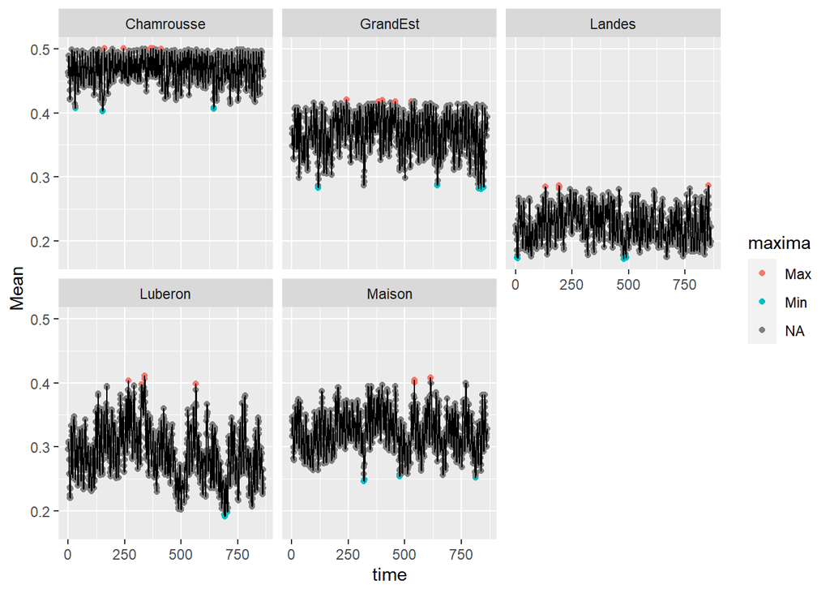

Figure 1: Temporal evolution of SWC weighted between 4 layers, red points and blues points represent the five maxima and minima selected to compute mean max and min SWC, respectively

# Texture maps

Texture was computed over two layers - topsoil and subsoil - according to the data format. Texture class almost never fall in the finest texture class. In some regions, namely Spain and Norway, texture differs between top soil and subsoil, while in most areas, no difference was observed.

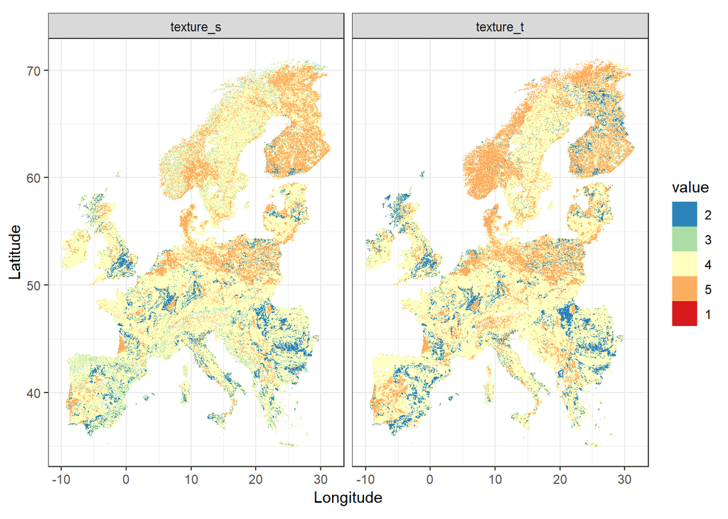

Figure 2: Map of soil texture according to the 5 classes defined by campbell

# Soil water content

Minima and maxima computed over Europe and the period 1950-2021.

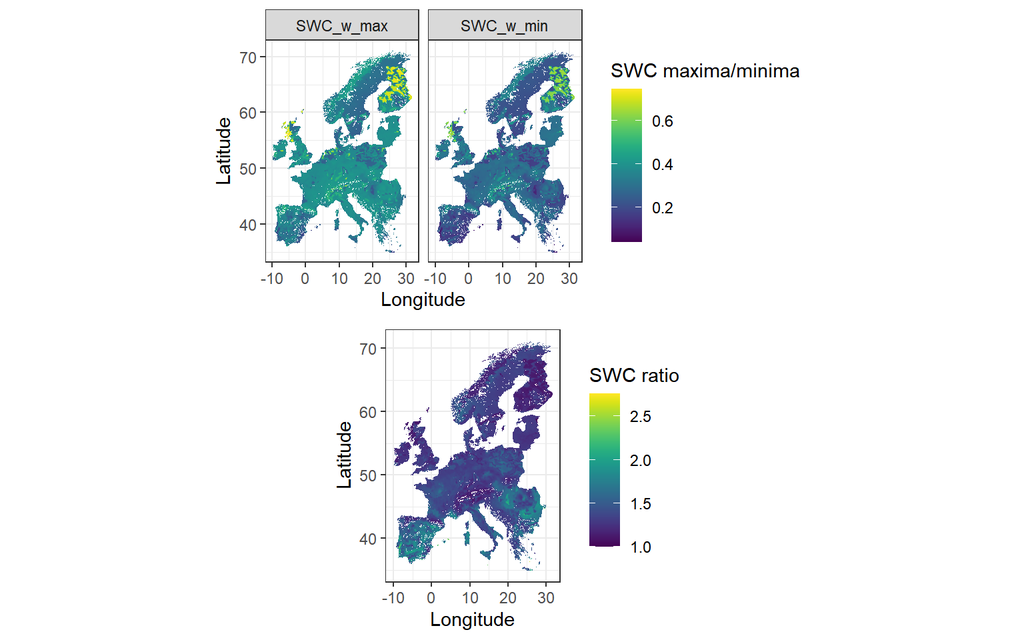

Figure 3: Soil water content minima and maxima, and ratio

# Comparison of minimum soil potential computation method

## Spatial comparison of the three computation methods

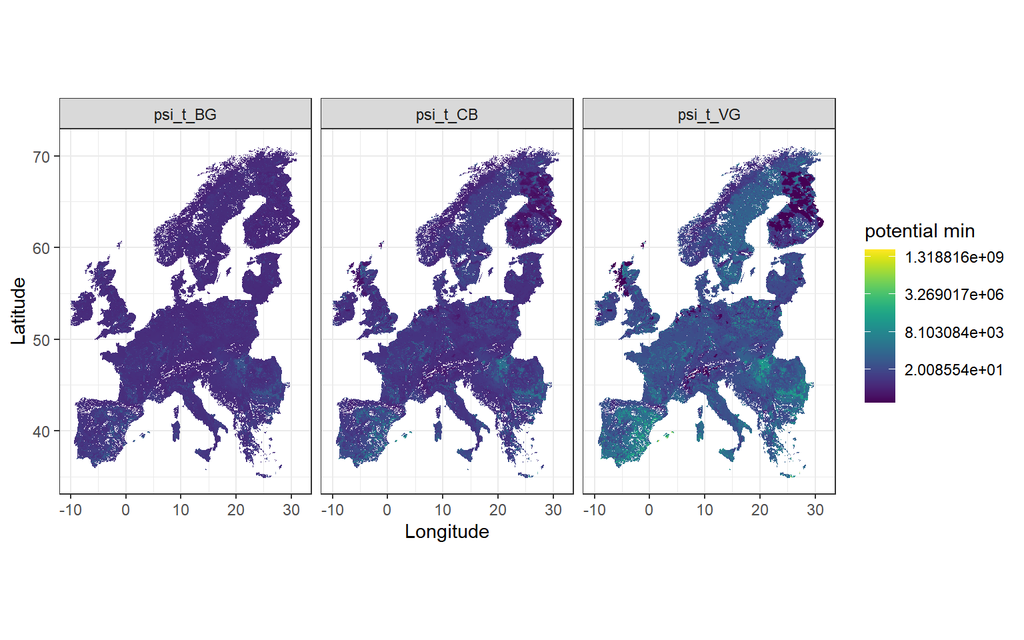

Figure 4: Minimum soil potential in topsoil for three computation methods: Benito-Garzon, Campbell, Van Genuchten

## Values distribution

The distribution of the minimum soil potentials is in an increasingly wide range of values depending on whether the BG, CB or VG method is used. For all methods, there is a systematically increasing ranking of potential values, from the coarsest to the finest textures.

In the VG distribution, a peak is observed at $10^{-4}$, which represents all values where the minimum soil moisture exceeded the $\theta_s$ parameter.

For the BG method, the parameter values are all very low, always below 0.1.

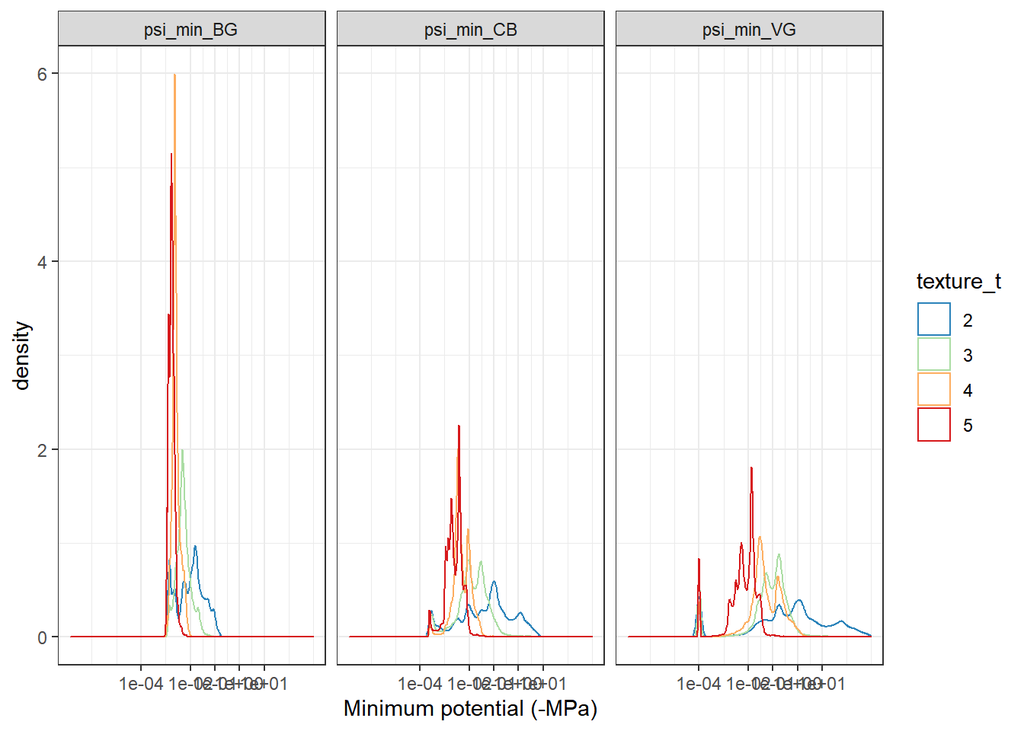

Figure 5: Minimum soil potential distribution according to corresponding soil texture

# Digging into Van Genuchen method

## Categories

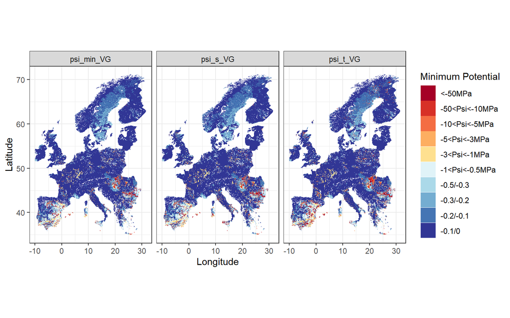

Figure 6: Minimum soil potential mapped with categories, for subsoil, topsoil and synthesis of both

## Potential distribution by texture class

Most of the minimum potential values range between 0 and 1MPa, which is very high.

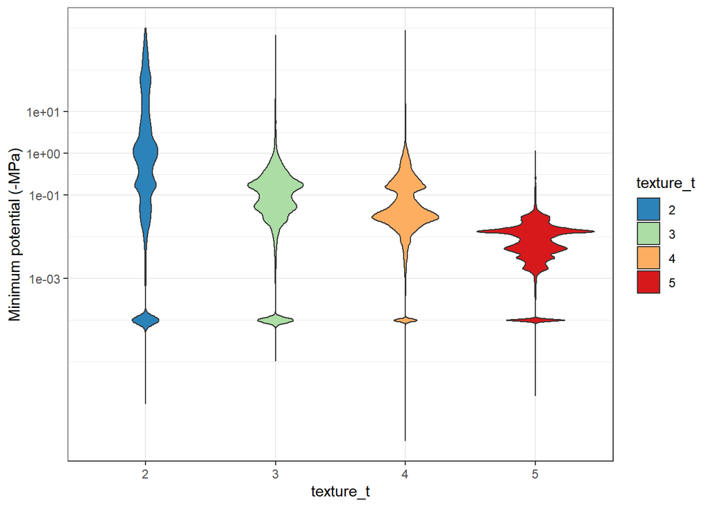

## Curves comparison

Comparison between 1A campbell curves 1B campbell computed pot, 2A vg curves 2B vg computed

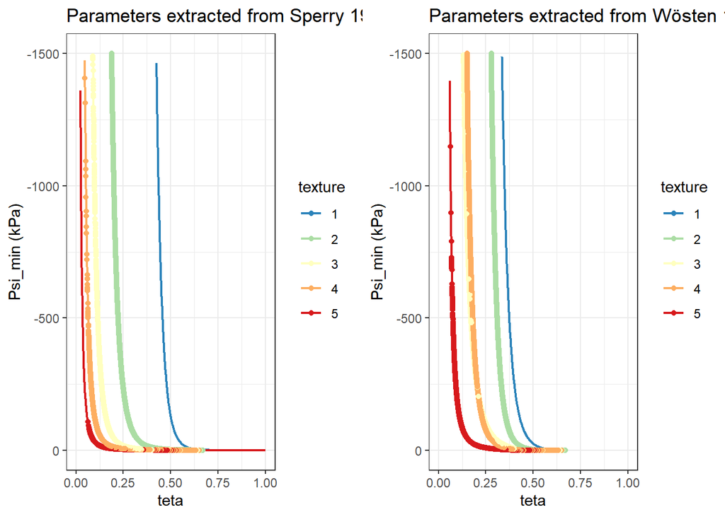

Figure 8: Water retention curves with theoritical function and observed data. Campbell function and Van Genuchten function

# Species distribution/HSM

13 european tree species were selected, with P50 spanning a representative gradient of values encontered in european species.

```
#>       Species.binomial    P50
#> 1           Salix alba   -1.5
#> 2       Betula pendula  -2.01
#> 3   Fraxinus excelsior   -2.8
#> 4     Pinus sylvestris  -3.09
#> 5      Fagus sylvatica  -3.15
#> 6           Abies alba  -3.79
#> 7      Ilex aquifolium -4.804
#> 8       Acer campestre  -5.74
#> 9    Sorbus torminalis  -6.21
#> 10    Cornus sanguinea  -6.37
#> 11 Acer monspessulanum  -6.74
#> 12       Quercus robur  -6.88
#> 13        Quercus ilex   -6.9
```

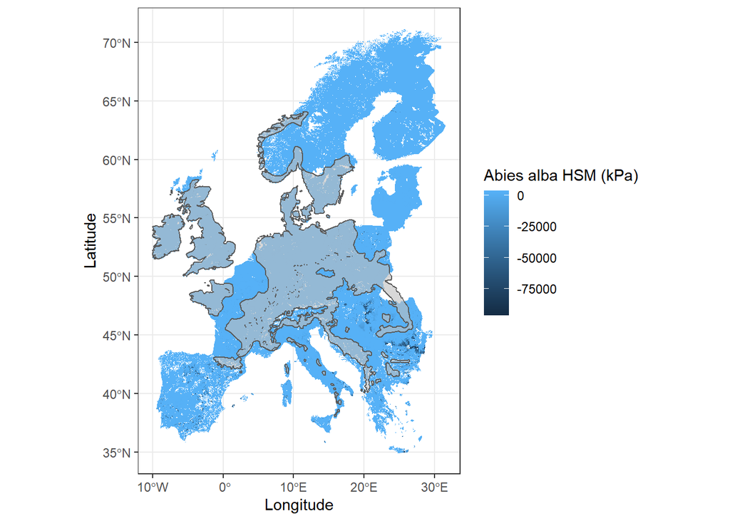

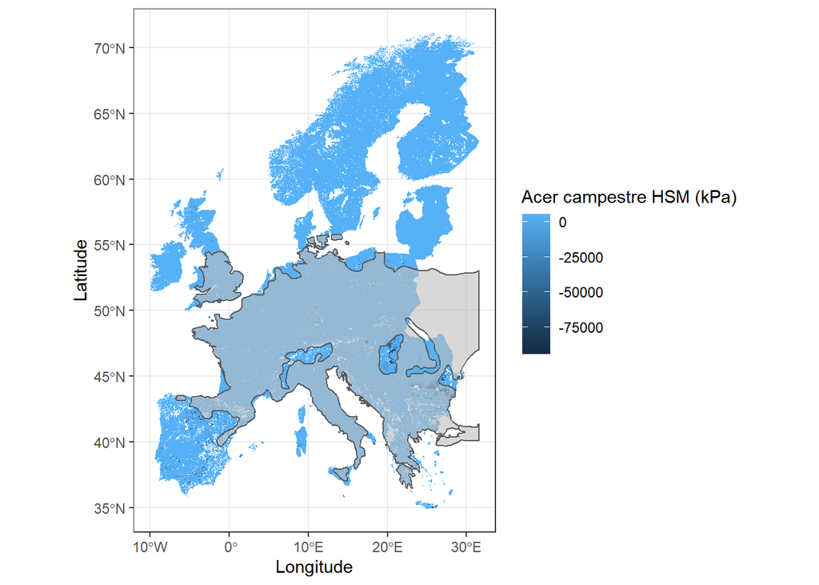

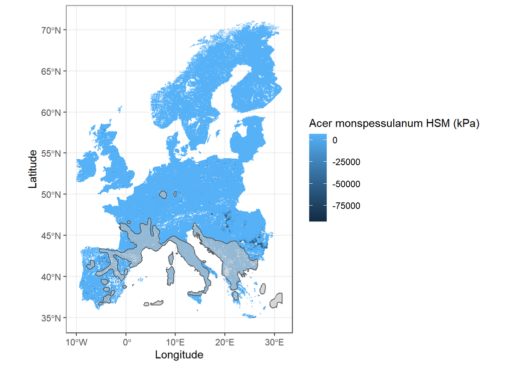

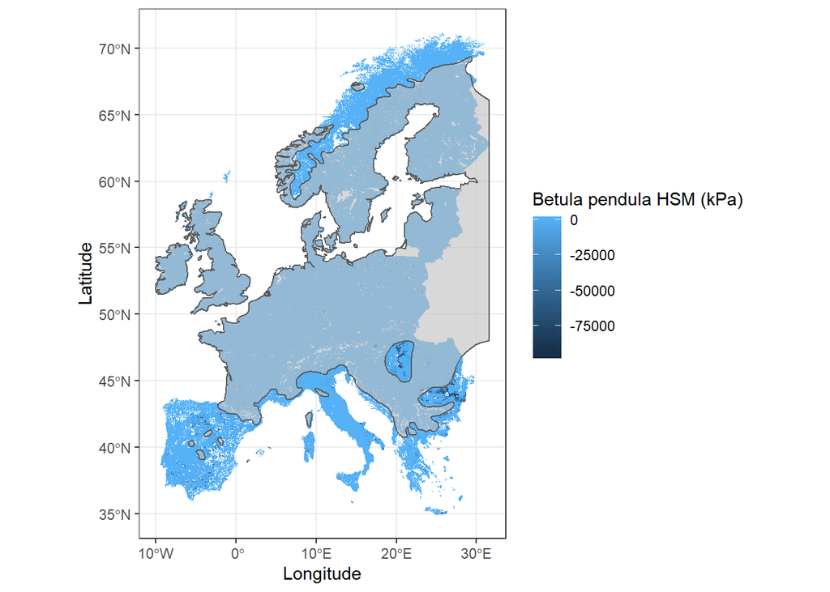

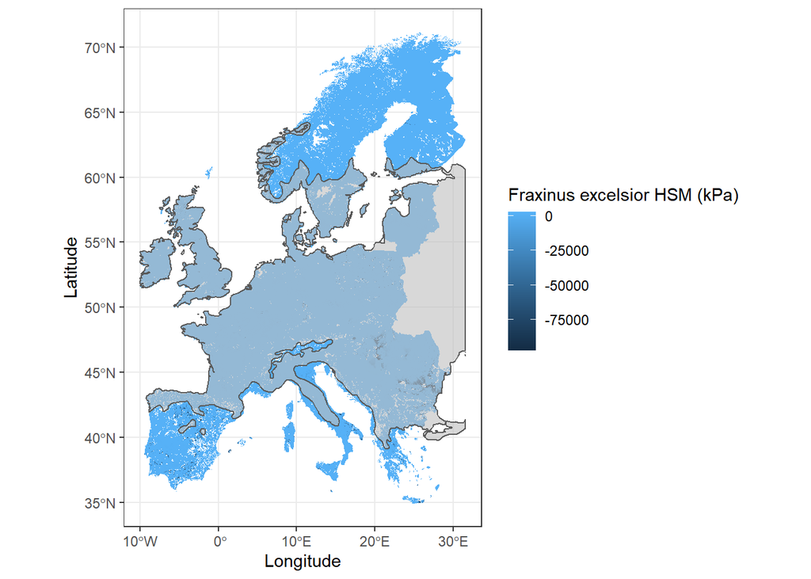

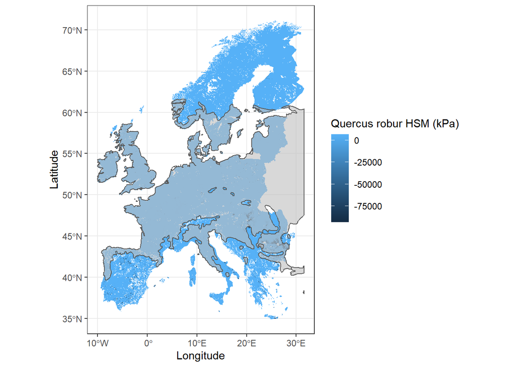

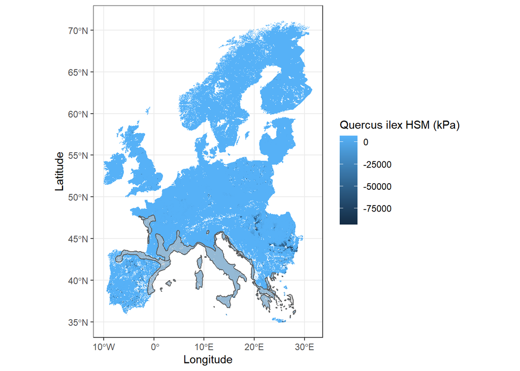